# JWST Data Analysis Use Case: NIRCam multiband photometry

## Analyzing simulated NIRCam imaging: JADES JWST GTO extragalactic blank field

http://fenrir.as.arizona.edu/jwstmock/

(Williams et al. 2018) https://ui.adsabs.harvard.edu/abs/2018ApJS..236...33W

In this example, we use `photutils` to detect objects in the simulated F200W image, then measure isophotal photometry in all 9 filters (F090W, F115W, F150W, F200W, F277W, F335M, F356W, F410M, F444W). We demonstrate loading the catalog back in and doing some simple analysis of the full catalog and of an individual galaxy.

Here we analyze only the central 1000 x 1000 pixels (30" x 30") of the full JADES simulation. These cutouts have been staged at STScI with permission from the authors (Williams et al.).

NOTE: The photometry is aperture matched, but no PSF corrections are made. For more accurate color measurements, PSF corrections should be implemented, given the large range of wavelengths (and thus PSF FWHM) spanning a factor of >4.

NOTE: The simulated JADES images have different units (e-/s) than JWST pipeline products (MJy/sr).

NOTE: An exposure map is missing but required to calculate flux uncertainties.

# To Do

- PSF corrections
- Check accuracy of photometry against simulated JADES catalog
- Exposure map required for input to error calculation
- ABmag units cannot be written to ecsv file (astropy update coming soon)
- plot with text labels looks horrible (I wish cursor hover would show id number instead)
- Fix plot secondary axis: mag vs. flux
- requirements.txt file -- but I don't know what versions are "required"
- rest of Robel's comments: https://github.com/spacetelescope/dat_pyinthesky/pull/82#pullrequestreview-355206337

## Import packages

```python
import os

import numpy as np

from astropy.convolution import Gaussian2DKernel
from astropy.io import fits
from astropy.stats import gaussian_fwhm_to_sigma
from astropy.table import QTable
import astropy.units as u
from astropy.visualization import make_lupton_rgb, SqrtStretch, ImageNormalize, simple_norm
import astropy.wcs as wcs

import photutils
print('photutils', photutils.__version__)
from photutils import Background2D, MedianBackground, detect_sources, deblend_sources, source_properties
from photutils.utils import calc_total_error
```

```
photutils 0.7.2
```

## Matplotlib setup for plotting

There are two versions

- `notebook` -- gives interactive plots, but makes the overall notebook a bit harder to scroll
- `inline` -- gives non-interactive plots for better overall scrolling

```python
import matplotlib.pyplot as plt
import matplotlib as mpl

# Use this version for non-interactive plots (easier scrolling of the notebook)
%matplotlib inline

# Use this version if you want interactive plots
# %matplotlib notebook

# These gymnastics are needed to make the sizes of the figures
# be the same in both the inline and notebook versions
%config InlineBackend.print_figure_kwargs = {'bbox_inches': None}

mpl.rcParams['savefig.dpi'] = 80
mpl.rcParams['figure.dpi'] = 80
```

## Create list of images to be loaded and analyzed

```python
baseurl = 'https://data.science.stsci.edu/redirect/JWST/jwst-data_analysis_tools/nircam_photometry/'

filters = 'F090W F115W F150W F200W F277W F335M F356W F410M F444W'.split()

# Data images [e-/s]
imagefiles = {}
for filt in filters:
    filename = f'jades_jwst_nircam_goods_s_crop_{filt}.fits'
    imagefiles[filt] = os.path.join(baseurl, filename)

# Weight images (Inverse Variance Maps; IVM)
weightfiles = {}
for filt in filters:
    filename = f'jades_jwst_nircam_goods_s_crop_{filt}_wht.fits'
    weightfiles[filt] = os.path.join(baseurl, filename)
```

## Load detection image: F200W

```python
filt = 'F200W'
infile = imagefiles[filt]
hdu = fits.open(infile)
data = hdu[0].data
imwcs = wcs.WCS(hdu[0].header, hdu)

weight = fits.open(weightfiles[filt])[0].data
```

## Report image size and field of view

```python
ny, nx = data.shape
pixscale = wcs.utils.proj_plane_pixel_scales(imwcs)[0]
pixscale *= imwcs.wcs.cunit[0].to('arcsec')
outline = '%d x %d pixels' % (ny, nx)
outline += ' = %g" x %g"' % (ny * pixscale, nx * pixscale)
outline += ' (%.2f" / pixel)' % pixscale
print(outline)
```

```
1000 x 1000 pixels = 30" x 30" (0.03" / pixel)
```

## Create color image (optional)

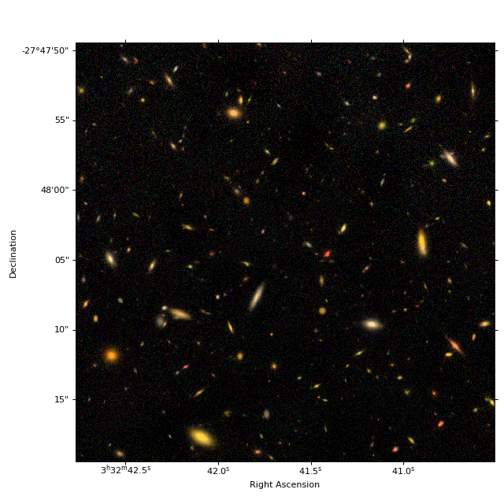

```python
# 3 NIRCam short wavelength channel images
r = fits.open(imagefiles['F200W'])[0].data
g = fits.open(imagefiles['F150W'])[0].data
b = fits.open(imagefiles['F090W'])[0].data

rgb = make_lupton_rgb(r, g, b, Q=5, stretch=0.02)  # , minimum=-0.001

fig = plt.figure(figsize=(8, 8))
ax = plt.subplot(projection=imwcs)
plt.imshow(rgb, origin='lower')
plt.xlabel('Right Ascension')
plt.ylabel('Declination')
fig.tight_layout()
plt.subplots_adjust(left=0.15)
```

## Detect Sources and Deblend using `photutils`

https://photutils.readthedocs.io/en/latest/segmentation.html

```python
# For detection, requiring 5 connected pixels 2-sigma above background

# Measure background and set detection threshold
bkg_estimator = MedianBackground()
bkg = Background2D(data, (50, 50), filter_size=(3, 3), bkg_estimator=bkg_estimator)
threshold = bkg.background + (2. * bkg.background_rms)

# Before detection, smooth image with Gaussian FWHM = 3 pixels
sigma = 3.0 * gaussian_fwhm_to_sigma
kernel = Gaussian2DKernel(sigma, x_size=3, y_size=3)
kernel.normalize()

# Detect and deblend
segm_detect = detect_sources(data, threshold, npixels=5, filter_kernel=kernel)
segm_deblend = deblend_sources(data, segm_detect, npixels=5, filter_kernel=kernel, nlevels=32, contrast=0.001)

# Save segmentation map of detected objects
segm_hdu = fits.PrimaryHDU(segm_deblend.data.astype(np.uint32), header=imwcs.to_header())
segm_hdu.writeto('JADES_detections_segm.fits', overwrite=True)
```

## Measure photometry (and more) in detection image

https://photutils.readthedocs.io/en/latest/segmentation.html#centroids-photometry-and-morphological-properties

```python
#error = bkg.background_rms
# Input weight should be exposure map. Fudging for now.
error = calc_total_error(data, bkg.background_rms, weight/500)
cat = source_properties(data-bkg.background, segm_deblend, wcs=imwcs, background=bkg.background, error=error)
```

## Show detections alongside images (optional)

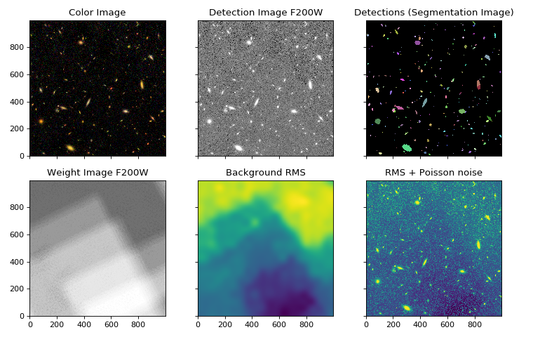

```python
fig, ax = plt.subplots(2, 3, sharex=True, sharey=True, figsize=(9.5, 6))
# For RA,Dec axes instead of pixels, add: , subplot_kw={'projection': imwcs})

# Color image
ax[0, 0].imshow(rgb, origin='lower')
ax[0, 0].set_title('Color Image')

# Data
norm = simple_norm(data, 'sqrt', percent=99.)
ax[0, 1].imshow(data, origin='lower', cmap='Greys_r', norm=norm)
ax[0, 1].set_title('Detection Image F200W')

# Segmentation map
cmap = segm_deblend.make_cmap(random_state=12345)
ax[0, 2].imshow(segm_deblend, origin='lower', cmap=cmap, interpolation='nearest')
ax[0, 2].set_title('Detections (Segmentation Image)')

# Weight
ax[1, 0].imshow(weight, origin='lower', cmap='Greys_r', vmin=0)
ax[1, 0].set_title('Weight Image F200W')

# RMS
ax[1, 1].imshow(bkg.background_rms, origin='lower', norm=None)
ax[1, 1].set_title('Background RMS')

# Total error including Poisson noise
norm = simple_norm(error, 'sqrt', percent=99.)
ax[1, 2].imshow(error, origin='lower', norm=norm)
ax[1, 2].set_title('RMS + Poisson noise')

fig.tight_layout()
```

## View all measured quantities in detection image (optional)

```python
cat.to_table()
```

*QTable length=330*

| id int64 | xcentroid pix float64 | ycentroid pix float64 | sky_centroid deg,deg object | sky_centroid_icrs deg,deg object | source_sum float64 | source_sum_err float64 | background_sum float64 | background_mean float64 | background_at_centroid float64 | bbox_xmin pix float64 | bbox_xmax pix float64 | bbox_ymin pix float64 | bbox_ymax pix float64 | min_value float64 | max_value float64 | minval_xpos pix float64 | minval_ypos pix float64 | maxval_xpos pix float64 | maxval_ypos pix float64 | area pix2 float64 | equivalent_radius pix float64 | perimeter pix float64 | semimajor_axis_sigma pix float64 | semiminor_axis_sigma pix float64 | orientation deg float64 | eccentricity float64 | ellipticity float64 | elongation float64 | covar_sigx2 pix2 float64 | … |
| --- | --- | --- | --- | --- | --- | --- | --- | --- | --- | --- | --- | --- | --- | --- | --- | --- | --- | --- | --- | --- | --- | --- | --- | --- | --- | --- | --- | --- | --- | --- |
| 1 | 466.2447477153619 | 8.797754695351568 | 53.173810089768665,-27.80532082877889 | 53.173810089768665,-27.80532082877889 | 0.8872549999433977 | 0.0433664460773928 | 0.01888389816578899 | 0.000186969288770188 | 0.00018749144292391748 | 460.0 | 472.0 | 3.0 | 14.0 | 0.0006771954827867622 | 0.03004444216769571 | 463.0 | 7.0 | 466.0 | 9.0 | 101.0 | 5.670035141386943 | 39.21320343559643 | 3.122740161781121 | 1.6882154213757017 | -44.480783359758476 | 0.8412669861232396 | 0.45938011684814906 | 1.8497284897661024 | 6.363326367232666 | … |
| 2 | 104.82669716468747 | 18.073062026314858 | 53.17721504245484,-27.805243269026736 | 53.17721504245484,-27.805243269026736 | 3.42840742385067 | 0.10129017448448854 | -0.02292890487629658 | -8.30757423054224e-05 | -8.210549326199463e-05 | 95.0 | 117.0 | 10.0 | 27.0 | 0.001256420266725895 | 0.05692831383933006 | 97.0 | 17.0 | 104.0 | 18.0 | 276.0 | 9.373021315815206 | 67.35533905932738 | 4.473864934080591 | 2.9145874846368325 | -26.47692816308998 | 0.7586746462479554 | 0.34853029146357106 | 1.5349907860590606 | 17.725496968836612 | … |
| 3 | 15.043834920643437 | 13.219056506614518 | 53.17806090163139,-27.805283640154833 | 53.17806090163139,-27.805283640154833 | 0.040553936939290415 | 0.011235859703560317 | 0.0009618608826096535 | 0.00012023261032620668 | 0.00012027377411975437 | 14.0 | 16.0 | 12.0 | 14.0 | 0.003552142274730671 | 0.0060460108741447445 | 16.0 | 12.0 | 14.0 | 14.0 | 8.0 | 1.5957691216057308 | 7.414213562373095 | 0.8501094923254491 | 0.6681830568491902 | -38.13244328970692 | 0.6182309884858855 | 0.21400353380198656 | 1.2722703510833258 | 0.6173690246394415 | … |
| 4 | 710.323383643416 | 14.260290158613083 | 53.17151059358405,-27.805275439752855 | 53.17151059358405,-27.805275439752855 | 0.15575573400825493 | 0.018561615449515574 | -0.0018083581859566619 | -7.233432743826647e-05 | -7.179586020992644e-05 | 708.0 | 712.0 | 12.0 | 17.0 | 0.00138483961044352 | 0.015132503295122899 | 709.0 | 17.0 | 710.0 | 14.0 | 25.0 | 2.8209479177387813 | 17.071067811865476 | 1.2767327019589096 | 1.1182847369487445 | -59.358171457252205 | 0.4825004141478757 | 0.12410425828919092 | 1.1416883909571123 | 1.3491371430694963 | … |
| 5 | 434.52841849748097 | 22.214000803618056 | 53.17410888331507,-27.80520900678579 | 53.17410888331507,-27.80520900678579 | 3.6125533400320746 | 0.08771652148254513 | 0.03926964992042564 | 0.00014707734052593873 | 0.00014671145267144666 | 424.0 | 447.0 | 14.0 | 30.0 | -0.00034053317824497446 | 0.10656309361696258 | 439.0 | 16.0 | 435.0 | 23.0 | 267.0 | 9.218933756735217 | 68.5269119345812 | 3.957029545770919 | 2.6224856903307496 | -8.194526936961696 | 0.7488487005078159 | 0.3372590070413968 | 1.5088850857645122 | 15.479694656358019 | … |
| 6 | 289.3877530021279 | 17.281804375084754 | 53.17547627312846,-27.80525000886962 | 53.17547627312846,-27.80525000886962 | 0.08525352624736104 | 0.016630118700831684 | -0.0005597903320903956 | -3.292884306414091e-05 | -3.245976856386993e-05 | 287.0 | 291.0 | 15.0 | 20.0 | 0.0019589311688638224 | 0.00880299024595394 | 288.0 | 18.0 | 291.0 | 17.0 | 17.0 | 2.326213245840639 | 13.485281374238571 | 1.2912775428181276 | 1.1977873819341411 | 68.14873465074655 | 0.37357815071904665 | 0.07240129080224722 | 1.078052384166063 | 1.4669313621805795 | … |
| 7 | 640.4864707749663 | 17.77332096909332 | 53.172168533005596,-27.80524613059388 | 53.172168533005596,-27.80524613059388 | 0.09706193595568358 | 0.014464857115946672 | -0.003572118411116578 | -0.00017010087671983704 | -0.0001701597850314308 | 638.0 | 642.0 | 15.0 | 20.0 | 0.0003559731695643122 | 0.009945696299542625 | 639.0 | 17.0 | 640.0 | 18.0 | 21.0 | 2.5854414729132054 | 15.071067811865476 | 1.5124631327692368 | 0.8802673830145178 | -64.72950205960183 | 0.8131822358940068 | 0.4179908495337691 | 1.7181860443240944 | 1.050535886519901 | … |
| 8 | 762.7521059555085 | 28.29850643371904 | 53.17101664985919,-27.805158478041616 | 53.17101664985919,-27.805158478041616 | 3.83286209357461 | 0.0885193575818851 | 0.008377006889888291 | 4.1266043792553155e-05 | 4.152512308191802e-05 | 754.0 | 771.0 | 21.0 | 36.0 | -0.00019722990813422726 | 0.10555947889140671 | 759.0 | 34.0 | 763.0 | 28.0 | 203.0 | 8.03846421247924 | 54.8700576850888 | 3.181893007267217 | 2.367212013134966 | 38.15638574745927 | 0.6682203418919801 | 0.2560365770538412 | 1.3441521036611106 | 8.398921457064766 | … |
| 9 | 801.1652202487488 | 32.616338554768426 | 53.17065475398638,-27.805122512146664 | 53.17065475398638,-27.805122512146664 | 0.06840424447364815 | 0.013111798920439961 | 0.0009877961248202778 | 6.585307498801852e-05 | 6.575431785787002e-05 | 799.0 | 804.0 | 31.0 | 34.0 | 0.0018946824308271285 | 0.00934488619101512 | 799.0 | 33.0 | 801.0 | 33.0 | 15.0 | 2.1850968611841584 | 12.449747468305834 | 1.451397482363723 | 0.692908571671924 | -26.710220397110557 | 0.8786818147210191 | 0.5225921361366398 | 2.094645010468893 | 1.7779652403020119 | … |
| ... | ... | ... | ... | ... | ... | ... | ... | ... | ... | ... | ... | ... | ... | ... | ... | ... | ... | ... | ... | ... | ... | ... | ... | ... | ... | ... | ... | ... | ... | … |
| 321 | 638.742655171455 | 555.4518209245798 | 53.17218465255342,-27.800765476121942 | 53.17218465255342,-27.800765476121942 | 8.68282276786065 | 0.1587978487855047 | 0.04198219437611292 | 0.0001639929467816911 | 0.00016233458236765495 | 630.0 | 647.0 | 544.0 | 568.0 | 0.0014525624231452527 | 0.2657901138099087 | 634.0 | 560.0 | 639.0 | 556.0 | 256.0 | 9.0270333367641 | 67.35533905932738 | 4.194490054000046 | 1.800579968756683 | 64.56722500938405 | 0.9031749386919365 | 0.5707273242811548 | 2.329521669007781 | 5.888948084970234 | … |
| 322 | 13.425340111208474 | 884.7189584304024 | 53.17807525512807,-27.798021140471008 | 53.17807525512807,-27.798021140471008 | 2.0985520561310933 | 0.10755150562965998 | 0.012657325057616253 | 6.954574207481457e-05 | 6.87452792195963e-05 | 6.0 | 21.0 | 877.0 | 892.0 | 0.001676582234993803 | 0.03489997111213739 | 13.0 | 878.0 | 13.0 | 886.0 | 182.0 | 7.611333607551958 | 51.62741699796952 | 3.273611037322288 | 3.130768130028977 | -13.068223384793171 | 0.29217347249304954 | 0.043634660827070015 | 1.0456255146854292 | 10.669757919580064 | … |
| 323 | 7.026406115063075 | 891.9731129391538 | 53.17813552870443,-27.79796068336358 | 53.17813552870443,-27.79796068336358 | 0.21280086086420566 | 0.03502511612433715 | 0.001359946755168421 | 4.689471569546279e-05 | 4.6798923340128445e-05 | 5.0 | 11.0 | 889.0 | 895.0 | 0.0018568857153893647 | 0.013429829797255835 | 9.0 | 893.0 | 7.0 | 892.0 | 29.0 | 3.0382538898732494 | 16.485281374238568 | 1.6025224485009613 | 1.3116165970136897 | -82.7514660600684 | 0.5745492228411223 | 0.18152996967960855 | 1.221791834709633 | 1.7338339282245565 | … |
| 324 | 143.93556906748591 | 953.7175838734796 | 53.176845721285815,-27.79744626508412 | 53.176845721285815,-27.79744626508412 | 0.5643013543026549 | 0.05733476274197878 | 0.013759797489299917 | 0.0002372378877465503 | 0.00023749377017116715 | 139.0 | 149.0 | 950.0 | 957.0 | 0.0021403850494273492 | 0.021149935003279982 | 141.0 | 956.0 | 143.0 | 953.0 | 58.0 | 4.296739856991561 | 29.31370849898476 | 2.6514851883814607 | 1.3827684391564974 | 24.763792878722448 | 0.8532469221063139 | 0.4784928668598081 | 1.917519313645091 | 6.132317149849681 | … |
| 325 | 142.73238143243003 | 959.531387718439 | 53.176857050411634,-27.79739781572983 | 53.176857050411634,-27.79739781572983 | 0.5601550325955892 | 0.05676609984629379 | 0.0108837521326575 | 0.0002315691943118617 | 0.0002317865033612348 | 139.0 | 147.0 | 957.0 | 963.0 | 0.0004510589224211869 | 0.030432433346262902 | 142.0 | 963.0 | 143.0 | 959.0 | 47.0 | 3.8678889139475245 | 23.899494936611667 | 2.1434885379958084 | 1.240008161216274 | -35.96440336511962 | 0.8156823691469608 | 0.4214999804124453 | 1.7286084116521836 | 3.540208117102293 | … |
| 326 | 790.4044022195777 | 955.3081976376485 | 53.17075570329054,-27.79743340975221 | 53.17075570329054,-27.79743340975221 | 1.1006558568504388 | 0.07864408275644322 | 0.011581260395358227 | 0.0001272665977511893 | 0.00012703515606830366 | 784.0 | 796.0 | 951.0 | 959.0 | 0.0005141812128670878 | 0.04015494027085132 | 789.0 | 951.0 | 791.0 | 956.0 | 91.0 | 5.382025607773058 | 34.970562748477136 | 2.587286524359811 | 1.8689490974299576 | 6.7848499931816075 | 0.691518485067743 | 0.27764123538949603 | 1.3843536605237983 | 6.649372819225033 | … |
| 327 | 797.326311864289 | 965.5066697644768 | 53.17069049120633,-27.79734842532586 | 53.17069049120633,-27.79734842532586 | 2.08902764854927 | 0.10600732273847185 | 0.01156711102220878 | 9.802636459498966e-05 | 9.847352674971637e-05 | 792.0 | 802.0 | 958.0 | 973.0 | 0.002240305440087749 | 0.08751019842702501 | 794.0 | 961.0 | 797.0 | 965.0 | 118.0 | 6.128667601500942 | 42.62741699796952 | 2.984456518668089 | 1.7418633259754384 | 80.35215406487414 | 0.8120088886862654 | 0.4163549326050153 | 1.7133700871719095 | 3.19904037370271 | … |
| 328 | 790.8040743796822 | 979.5811869488293 | 53.17075192691637,-27.797231135019413 | 53.17075192691637,-27.797231135019413 | 1.9874922807505606 | 0.10371185756040696 | 0.014568820505891936 | 0.00011036985231736314 | 0.00010659901197830513 | 781.0 | 799.0 | 972.0 | 989.0 | -0.001359951050577134 | 0.06932730354023382 | 792.0 | 983.0 | 791.0 | 980.0 | 132.0 | 6.4820448144285745 | 54.526911934581186 | 4.496400722509251 | 1.4882932367652355 | -44.22750525993711 | 0.9436319556183236 | 0.6690034254921385 | 3.0211793021931985 | 11.459010165592927 | … |
| 329 | 307.7499498474376 | 989.9940620863264 | 53.17530248914979,-27.797144087687016 | 53.17530248914979,-27.797144087687016 | 0.3901794527798415 | 0.04614859839712915 | -0.004868161452484149 | -0.00013157193114822025 | -0.00013193197798635312 | 305.0 | 311.0 | 987.0 | 993.0 | 0.001869217533432865 | 0.030607716660593504 | 310.0 | 991.0 | 308.0 | 990.0 | 37.0 | 3.431831258788849 | 21.071067811865476 | 1.7097280575352152 | 1.1938377397787487 | -56.766372052958886 | 0.7158425109409574 | 0.3017382299382665 | 1.4321276674098737 | 1.8751694154972454 | … |
| 330 | 306.87737513482 | 997.1712852179836 | 53.17531070331411,-27.79708427687015 | 53.17531070331411,-27.79708427687015 | 0.5685355251469956 | 0.055361057214691665 | -0.006547195642548069 | -0.00012124436375089016 | -0.00012140868643165816 | 302.0 | 312.0 | 993.0 | 999.0 | 0.0029225170128293967 | 0.02053868262384249 | 308.0 | 994.0 | 308.0 | 998.0 | 54.0 | 4.145929793656026 | 27.89949493661166 | 2.5218245497579255 | 1.548497945530416 | 15.760034247508301 | 0.7892758942379959 | 0.3859612693202391 | 1.6285617666054508 | 6.0673347857120845 | … |

## Only keep some quantities

```python
columns = 'id xcentroid ycentroid sky_centroid area semimajor_axis_sigma semiminor_axis_sigma ellipticity orientation gini'.split()
tbl = cat.to_table(columns=columns)
tbl.rename_column('semimajor_axis_sigma', 'a')
tbl.rename_column('semiminor_axis_sigma', 'b')
```

```python
tbl
```

*QTable length=330*

| id int64 | xcentroid pix float64 | ycentroid pix float64 | sky_centroid deg,deg object | area pix2 float64 | a pix float64 | b pix float64 | ellipticity float64 | orientation deg float64 | gini float64 |
| --- | --- | --- | --- | --- | --- | --- | --- | --- | --- |
| 1 | 466.2447477153619 | 8.797754695351568 | 53.173810089768665,-27.80532082877889 | 101.0 | 3.122740161781121 | 1.6882154213757017 | 0.45938011684814906 | -44.480783359758476 | 0.37470095435062684 |
| 2 | 104.82669716468747 | 18.073062026314858 | 53.17721504245484,-27.805243269026736 | 276.0 | 4.473864934080591 | 2.9145874846368325 | 0.34853029146357106 | -26.47692816308998 | 0.42942305468196934 |
| 3 | 15.043834920643437 | 13.219056506614518 | 53.17806090163139,-27.805283640154833 | 8.0 | 0.8501094923254491 | 0.6681830568491902 | 0.21400353380198656 | -38.13244328970692 | 0.10562361979329521 |
| 4 | 710.323383643416 | 14.260290158613083 | 53.17151059358405,-27.805275439752855 | 25.0 | 1.2767327019589096 | 1.1182847369487445 | 0.12410425828919092 | -59.358171457252205 | 0.33566355246243296 |
| 5 | 434.52841849748097 | 22.214000803618056 | 53.17410888331507,-27.80520900678579 | 267.0 | 3.957029545770919 | 2.6224856903307496 | 0.3372590070413968 | -8.194526936961696 | 0.535709175346461 |
| 6 | 289.3877530021279 | 17.281804375084754 | 53.17547627312846,-27.80525000886962 | 17.0 | 1.2912775428181276 | 1.1977873819341411 | 0.07240129080224722 | 68.14873465074655 | 0.1801528140791572 |
| 7 | 640.4864707749663 | 17.77332096909332 | 53.172168533005596,-27.80524613059388 | 21.0 | 1.5124631327692368 | 0.8802673830145178 | 0.4179908495337691 | -64.72950205960183 | 0.25739395085982053 |
| 8 | 762.7521059555085 | 28.29850643371904 | 53.17101664985919,-27.805158478041616 | 203.0 | 3.181893007267217 | 2.367212013134966 | 0.2560365770538412 | 38.15638574745927 | 0.5441155385702788 |
| 9 | 801.1652202487488 | 32.616338554768426 | 53.17065475398638,-27.805122512146664 | 15.0 | 1.451397482363723 | 0.692908571671924 | 0.5225921361366398 | -26.710220397110557 | 0.2960813250955592 |
| ... | ... | ... | ... | ... | ... | ... | ... | ... | ... |
| 321 | 638.742655171455 | 555.4518209245798 | 53.17218465255342,-27.800765476121942 | 256.0 | 4.194490054000046 | 1.800579968756683 | 0.5707273242811548 | 64.56722500938405 | 0.638665863816285 |
| 322 | 13.425340111208474 | 884.7189584304024 | 53.17807525512807,-27.798021140471008 | 182.0 | 3.273611037322288 | 3.130768130028977 | 0.043634660827070015 | -13.068223384793171 | 0.3277655936818248 |
| 323 | 7.026406115063075 | 891.9731129391538 | 53.17813552870443,-27.79796068336358 | 29.0 | 1.6025224485009613 | 1.3116165970136897 | 0.18152996967960855 | -82.7514660600684 | 0.2556620915166148 |
| 324 | 143.93556906748591 | 953.7175838734796 | 53.176845721285815,-27.79744626508412 | 58.0 | 2.6514851883814607 | 1.3827684391564974 | 0.4784928668598081 | 24.763792878722448 | 0.2771733746621636 |
| 325 | 142.73238143243003 | 959.531387718439 | 53.176857050411634,-27.79739781572983 | 47.0 | 2.1434885379958084 | 1.240008161216274 | 0.4214999804124453 | -35.96440336511962 | 0.3346925635894147 |
| 326 | 790.4044022195777 | 955.3081976376485 | 53.17075570329054,-27.79743340975221 | 91.0 | 2.587286524359811 | 1.8689490974299576 | 0.27764123538949603 | 6.7848499931816075 | 0.3741269170834157 |
| 327 | 797.326311864289 | 965.5066697644768 | 53.17069049120633,-27.79734842532586 | 118.0 | 2.984456518668089 | 1.7418633259754384 | 0.4163549326050153 | 80.35215406487414 | 0.47680329459429227 |
| 328 | 790.8040743796822 | 979.5811869488293 | 53.17075192691637,-27.797231135019413 | 132.0 | 4.496400722509251 | 1.4882932367652355 | 0.6690034254921385 | -44.22750525993711 | 0.42254576260050036 |
| 329 | 307.7499498474376 | 989.9940620863264 | 53.17530248914979,-27.797144087687016 | 37.0 | 1.7097280575352152 | 1.1938377397787487 | 0.3017382299382665 | -56.766372052958886 | 0.35613133574474776 |
| 330 | 306.87737513482 | 997.1712852179836 | 53.17531070331411,-27.79708427687015 | 54.0 | 2.5218245497579255 | 1.548497945530416 | 0.3859612693202391 | 15.760034247508301 | 0.25254216183898764 |

## Convert measured fluxes (data units) to magnitudes

https://docs.astropy.org/en/stable/units/

https://docs.astropy.org/en/stable/units/equivalencies.html#photometric-zero-point-equivalency

https://docs.astropy.org/en/stable/units/logarithmic_units.html#logarithmic-units

```python
# not detected: mag =  99; magerr = 1-sigma upper limit assuming zero flux
# not observed: mag = -99; magerr = 0
def fluxes2mags(flux, fluxerr):
    nondet = flux < 0  # Non-detection if flux is negative
    unobs = (fluxerr <= 0) + (fluxerr == np.inf)  # Unobserved if flux uncertainty is negative or infinity

    mag = flux.to(u.ABmag)
    magupperlimit = fluxerr.to(u.ABmag)  # 1-sigma upper limit if flux=0

    mag = np.where(nondet, 99 * u.ABmag, mag)
    mag = np.where(unobs, -99 * u.ABmag, mag)

    magerr = 2.5 * np.log10(1 + fluxerr/flux)
    magerr = magerr.value * u.ABmag

    magerr = np.where(nondet, magupperlimit, magerr)
    magerr = np.where(unobs, 0*u.ABmag, magerr)

    return mag, magerr

# Includes features I couldn't find in astropy:
# mag = 99 / -99 for non-detections / unobserved
# flux uncertainties -> mag uncertainties
```

## Multiband photometry using isophotal apertures defined in detection image

(Similar to running SourceExtractor in double-image mode)

```python
filters = 'F090W F115W F150W F200W F277W F335M F356W F410M F444W'.split()
for filt in filters:
    infile = imagefiles[filt]
    print(filt)
    print(infile)
    print(weightfiles[filt])
    hdu = fits.open(infile)
    data = hdu[0].data
    zp = hdu[0].header['ABMAG'] * u.ABmag  # zeropoint
    weight = fits.open(weightfiles[filt])[0].data

    # Measure background
    bkg = Background2D(data, (50, 50), filter_size=(3, 3), bkg_estimator=bkg_estimator)
    #error = bkg.background_rms
    error = calc_total_error(data, bkg.background_rms, weight/500)

    # Measure properties in each image of previously detected objects
    filtcat = source_properties(data-bkg.background, segm_deblend, wcs=imwcs, background=bkg.background, error=error)

    # Convert measured fluxes to fluxes in nJy and to AB magnitudes
    filttbl = filtcat.to_table()
    tbl[filt+'_flux']    = flux    = filttbl['source_sum']     * zp.to(u.nJy)
    tbl[filt+'_fluxerr'] = fluxerr = filttbl['source_sum_err'] * zp.to(u.nJy)

    mag, magerr = fluxes2mags(flux, fluxerr)
    #mag = mag * u.ABmag  # incompatible with file writing
    tbl[filt+'_mag']    = mag.value
    tbl[filt+'_magerr'] = magerr.value
```

```
F090W
https://data.science.stsci.edu/redirect/JWST/jwst-data_analysis_tools/nircam_photometry/jades_jwst_nircam_goods_s_crop_F090W.fits
https://data.science.stsci.edu/redirect/JWST/jwst-data_analysis_tools/nircam_photometry/jades_jwst_nircam_goods_s_crop_F090W_wht.fits
F115W
https://data.science.stsci.edu/redirect/JWST/jwst-data_analysis_tools/nircam_photometry/jades_jwst_nircam_goods_s_crop_F115W.fits
https://data.science.stsci.edu/redirect/JWST/jwst-data_analysis_tools/nircam_photometry/jades_jwst_nircam_goods_s_crop_F115W_wht.fits
F150W
https://data.science.stsci.edu/redirect/JWST/jwst-data_analysis_tools/nircam_photometry/jades_jwst_nircam_goods_s_crop_F150W.fits
https://data.science.stsci.edu/redirect/JWST/jwst-data_analysis_tools/nircam_photometry/jades_jwst_nircam_goods_s_crop_F150W_wht.fits
F200W
https://data.science.stsci.edu/redirect/JWST/jwst-data_analysis_tools/nircam_photometry/jades_jwst_nircam_goods_s_crop_F200W.fits
https://data.science.stsci.edu/redirect/JWST/jwst-data_analysis_tools/nircam_photometry/jades_jwst_nircam_goods_s_crop_F200W_wht.fits
F277W
https://data.science.stsci.edu/redirect/JWST/jwst-data_analysis_tools/nircam_photometry/jades_jwst_nircam_goods_s_crop_F277W.fits
https://data.science.stsci.edu/redirect/JWST/jwst-data_analysis_tools/nircam_photometry/jades_jwst_nircam_goods_s_crop_F277W_wht.fits
F335M
https://data.science.stsci.edu/redirect/JWST/jwst-data_analysis_tools/nircam_photometry/jades_jwst_nircam_goods_s_crop_F335M.fits
https://data.science.stsci.edu/redirect/JWST/jwst-data_analysis_tools/nircam_photometry/jades_jwst_nircam_goods_s_crop_F335M_wht.fits
F356W
https://data.science.stsci.edu/redirect/JWST/jwst-data_analysis_tools/nircam_photometry/jades_jwst_nircam_goods_s_crop_F356W.fits
https://data.science.stsci.edu/redirect/JWST/jwst-data_analysis_tools/nircam_photometry/jades_jwst_nircam_goods_s_crop_F356W_wht.fits
F410M
https://data.science.stsci.edu/redirect/JWST/jwst-data_analysis_tools/nircam_photometry/jades_jwst_nircam_goods_s_crop_F410M.fits
https://data.science.stsci.edu/redirect/JWST/jwst-data_analysis_tools/nircam_photometry/jades_jwst_nircam_goods_s_crop_F410M_wht.fits
F444W
https://data.science.stsci.edu/redirect/JWST/jwst-data_analysis_tools/nircam_photometry/jades_jwst_nircam_goods_s_crop_F444W.fits
https://data.science.stsci.edu/redirect/JWST/jwst-data_analysis_tools/nircam_photometry/jades_jwst_nircam_goods_s_crop_F444W_wht.fits
```

## View complete results (optional)

```python
tbl
```

*QTable length=330*

| id int64 | xcentroid pix float64 | ycentroid pix float64 | sky_centroid deg,deg object | area pix2 float64 | a pix float64 | b pix float64 | ellipticity float64 | orientation deg float64 | gini float64 | F090W_flux nJy float64 | F090W_fluxerr nJy float64 | F090W_mag float64 | F090W_magerr float64 | F115W_flux nJy float64 | F115W_fluxerr nJy float64 | F115W_mag float64 | F115W_magerr float64 | F150W_flux nJy float64 | F150W_fluxerr nJy float64 | F150W_mag float64 | F150W_magerr float64 | F200W_flux nJy float64 | F200W_fluxerr nJy float64 | F200W_mag float64 | F200W_magerr float64 | F277W_flux nJy float64 | F277W_fluxerr nJy float64 | F277W_mag float64 | F277W_magerr float64 | … |
| --- | --- | --- | --- | --- | --- | --- | --- | --- | --- | --- | --- | --- | --- | --- | --- | --- | --- | --- | --- | --- | --- | --- | --- | --- | --- | --- | --- | --- | --- | --- |
| 1 | 466.2447477153619 | 8.797754695351568 | 53.173810089768665,-27.80532082877889 | 101.0 | 3.122740161781121 | 1.6882154213757017 | 0.45938011684814906 | -44.480783359758476 | 0.37470095435062684 | 9.157269619866208 | 0.8476839886346358 | 28.995584996449534 | 0.09612269449260587 | 15.28104270245901 | 0.7353956364493296 | 28.439617526626918 | 0.05103239186950971 | 18.356677849420983 | 0.9082626049752516 | 28.240514784173165 | 0.05243396167144997 | 20.376446821038343 | 0.9959415076497669 | 28.127178861490208 | 0.05181150288696084 | 15.29040186299257 | 0.37204816464763435 | 28.43895275072906 | 0.0261019966077274 | … |
| 2 | 104.82669716468747 | 18.073062026314858 | 53.17721504245484,-27.805243269026736 | 276.0 | 4.473864934080591 | 2.9145874846368325 | 0.34853029146357106 | -26.47692816308998 | 0.42942305468196934 | 67.54549493394877 | 2.447391619447084 | 26.82600902928334 | 0.038643790476554946 | 68.37315801804817 | 1.7880797142708318 | 26.812785901129747 | 0.028029005943424515 | 71.06526660739088 | 2.1171512800668455 | 26.770856525828645 | 0.03187341113726383 | 78.73583305521284 | 2.326201434771902 | 26.65956893287557 | 0.03161268147259503 | 73.33218651286762 | 0.8358134259022793 | 26.736763414119586 | 0.01230483339413912 | … |
| 3 | 15.043834920643437 | 13.219056506614518 | 53.17806090163139,-27.805283640154833 | 8.0 | 0.8501094923254491 | 0.6681830568491902 | 0.21400353380198656 | -38.13244328970692 | 0.10562361979329521 | 0.30019122251480157 | 0.22000506810850823 | 32.70650502631046 | 0.5969231539014093 | 0.7680861734697926 | 0.20092135383591664 | 31.686475131682425 | 0.2522930084028303 | 0.7174139844376631 | 0.22419792919246243 | 31.76057540485923 | 0.29525526667976065 | 0.9313502200381064 | 0.2580395689546411 | 31.477217446232913 | 0.2655279605482011 | 0.35067749105904555 | 0.06909640198197252 | 32.53773027322448 | 0.19526883584858087 | … |
| 4 | 710.323383643416 | 14.260290158613083 | 53.17151059358405,-27.805275439752855 | 25.0 | 1.2767327019589096 | 1.1182847369487445 | 0.12410425828919092 | -59.358171457252205 | 0.33566355246243296 | 2.673381929043971 | 0.4364107435992636 | 30.33234747981335 | 0.1641760696405685 | 3.828240745323026 | 0.3596903181483051 | 29.942501896753573 | 0.09750070737445107 | 3.989257579446315 | 0.4237283037967994 | 29.89776980285749 | 0.10960114830562225 | 3.5770420355968335 | 0.426280798805018 | 30.016189890527436 | 0.12224142483713438 | 1.715254365285117 | 0.12554069239758853 | 30.814178666825292 | 0.07669226590721422 | … |
| 5 | 434.52841849748097 | 22.214000803618056 | 53.17410888331507,-27.80520900678579 | 267.0 | 3.957029545770919 | 2.6224856903307496 | 0.3372590070413968 | -8.194526936961696 | 0.535709175346461 | 48.064017094107285 | 1.7904649343479864 | 27.195449836384554 | 0.0397103574834327 | 54.126102855393846 | 1.3655937339589115 | 27.066483103772782 | 0.027053111344790826 | 58.105769988875004 | 1.6251189798709333 | 26.98945184846021 | 0.029949294349657093 | 82.9648759669137 | 2.0144727676142393 | 26.602764329370103 | 0.02604782541115786 | 132.8712265292278 | 1.0545579581725046 | 26.09142264005316 | 0.008583137522626086 | … |
| 6 | 289.3877530021279 | 17.281804375084754 | 53.17547627312846,-27.80525000886962 | 17.0 | 1.2912775428181276 | 1.1977873819341411 | 0.07240129080224722 | 68.14873465074655 | 0.1801528140791572 | 1.1437044255812994 | 0.3810505188517289 | 31.2542154959485 | 0.3122156218237949 | 1.5003250994677342 | 0.2863021823203722 | 30.959536563015845 | 0.18962146645986802 | 1.054631886469934 | 0.28866331897839687 | 31.34224775511571 | 0.2626764167368348 | 1.9579083172212846 | 0.38192259199065626 | 30.670519121803505 | 0.19348030608786954 | 1.1897901634043437 | 0.12366148032282878 | 31.2113240648196 | 0.10735928570050962 | … |
| 7 | 640.4864707749663 | 17.77332096909332 | 53.172168533005596,-27.80524613059388 | 21.0 | 1.5124631327692368 | 0.8802673830145178 | 0.4179908495337691 | -64.72950205960183 | 0.25739395085982053 | 1.7283147754888688 | 0.3543256121797585 | 30.805942893056972 | 0.20247860857196265 | 1.626628973342165 | 0.24984272839052085 | 30.871778740899707 | 0.15513378937250225 | 1.631053253648278 | 0.2841409368011637 | 30.868829647693566 | 0.17436168688191606 | 2.229096907286167 | 0.3321958082127556 | 30.52967762670788 | 0.15082566255242066 | 1.036439695304672 | 0.09605822308190612 | 31.361139905074175 | 0.0962334361261899 | … |
| 8 | 762.7521059555085 | 28.29850643371904 | 53.17101664985919,-27.805158478041616 | 203.0 | 3.181893007267217 | 2.367212013134966 | 0.2560365770538412 | 38.15638574745927 | 0.5441155385702788 | 53.018382299142736 | 1.7904311574671414 | 27.08893381906643 | 0.036059819648105375 | 56.02459318473886 | 1.3388954361537875 | 27.029053220885174 | 0.02564210973168307 | 61.82442746561358 | 1.6297462163653142 | 26.92209974199313 | 0.02825022443871256 | 88.02442435047321 | 2.032910473894006 | 26.5384920159634 | 0.024789741501437583 | 86.38923297594539 | 0.7884036820748288 | 26.558850954871023 | 0.009863683210512371 | … |
| 9 | 801.1652202487488 | 32.616338554768426 | 53.17065475398638,-27.805122512146664 | 15.0 | 1.451397482363723 | 0.692908571671924 | 0.5225921361366398 | -26.710220397110557 | 0.2960813250955592 | 1.2733308727083092 | 0.32313724507002084 | 31.137646827628984 | 0.2455474523697915 | 1.4870990688390437 | 0.24958015211060774 | 30.969150245781606 | 0.1684492659396858 | 1.5292396561870243 | 0.2848837002269411 | 30.93881112099577 | 0.18547815799949363 | 1.570952488224374 | 0.30112185724232265 | 30.90959237383228 | 0.1904001034069584 | 1.3130736820157525 | 0.1107090099318852 | 31.10427725790078 | 0.08788653085477502 | … |
| ... | ... | ... | ... | ... | ... | ... | ... | ... | ... | ... | ... | ... | ... | ... | ... | ... | ... | ... | ... | ... | ... | ... | ... | ... | ... | ... | ... | ... | ... | … |
| 321 | 638.742655171455 | 555.4518209245798 | 53.17218465255342,-27.800765476121942 | 256.0 | 4.194490054000046 | 1.800579968756683 | 0.5707273242811548 | 64.56722500938405 | 0.638665863816285 | 119.8913844361272 | 3.1484619156842295 | 26.203030061983625 | 0.02814451229553952 | 164.75763576549096 | 2.6632960727177393 | 25.857886121744258 | 0.017410508777602952 | 210.57392369890863 | 3.5245943952595433 | 25.59148852607247 | 0.018022679295109735 | 199.40724639151134 | 3.6469063812314926 | 25.65064765905959 | 0.019677348843205458 | 142.98354083460833 | 1.1919384227563465 | 26.011784880744845 | 0.009013390081419392 | … |
| 322 | 13.425340111208474 | 884.7189584304024 | 53.17807525512807,-27.798021140471008 | 182.0 | 3.273611037322288 | 3.130768130028977 | 0.043634660827070015 | -13.068223384793171 | 0.3277655936818248 | 18.487710785469446 | 1.9583562226660072 | 28.232792153522865 | 0.10931660297101999 | 31.64984851183555 | 1.7095710593890685 | 27.649070910848895 | 0.05711712493527022 | 50.01369635493332 | 2.404046142148252 | 27.152277617318706 | 0.05097339987090793 | 48.19475165049938 | 2.4699973909701045 | 27.192500633310072 | 0.05426537279709328 | 36.627022629394695 | 0.8181289001400059 | 27.49049595806008 | 0.02398493903093088 | … |
| 323 | 7.026406115063075 | 891.9731129391538 | 53.17813552870443,-27.79796068336358 | 29.0 | 1.6025224485009613 | 1.3116165970136897 | 0.18152996967960855 | -82.7514660600684 | 0.2556620915166148 | 4.429203334624113 | 0.8830412416479638 | 29.784185954470868 | 0.19738110892507474 | 3.505089069974359 | 0.5911517346083803 | 30.0382523535822 | 0.1692160522537607 | 5.082960104459169 | 0.7851861699802262 | 29.63470824752232 | 0.15596057477819417 | 4.887124248550066 | 0.804376888441066 | 29.677366548698373 | 0.1654336160613057 | 4.006916667952617 | 0.2839025747024874 | 29.892974223793885 | 0.07432477278524138 | … |
| 324 | 143.93556906748591 | 953.7175838734796 | 53.176845721285815,-27.79744626508412 | 58.0 | 2.6514851883814607 | 1.3827684391564974 | 0.4784928668598081 | 24.763792878722448 | 0.2771733746621636 | 5.129740011075819 | 1.0728974454098918 | 29.624761613836643 | 0.20620260743538155 | 5.74632987742709 | 0.797644209189774 | 29.501523615615632 | 0.1411275428920821 | 7.071232516070177 | 0.9936540808093035 | 29.276262205155486 | 0.14275786766826795 | 12.959584942008224 | 1.316733908609488 | 28.618522268594507 | 0.10506286615868195 | 8.22924203203302 | 0.4173842071431854 | 29.11160041089549 | 0.053717127094940864 | … |
| 325 | 142.73238143243003 | 959.531387718439 | 53.176857050411634,-27.79739781572983 | 47.0 | 2.1434885379958084 | 1.240008161216274 | 0.4214999804124453 | -35.96440336511962 | 0.3346925635894147 | 6.706736411082818 | 1.12825190466007 | 29.333721905037645 | 0.16881778790042382 | 7.8476794859762276 | 0.8679975444942872 | 29.163146856678065 | 0.11389967814365409 | 10.17818402374969 | 1.124903096930391 | 28.880824253135945 | 0.11381694068735779 | 12.864361693029823 | 1.3036741577444468 | 28.626529394615858 | 0.10480351241946276 | 8.854767736669611 | 0.42025745562937683 | 29.032057065011884 | 0.050344809748888456 | … |
| 326 | 790.4044022195777 | 955.3081976376485 | 53.17075570329054,-27.79743340975221 | 91.0 | 2.587286524359811 | 1.8689490974299576 | 0.27764123538949603 | 6.7848499931816075 | 0.3741269170834157 | 20.39066434589152 | 1.860594296506638 | 28.12642156073187 | 0.09480801542740658 | 27.812881690759095 | 1.534453941567089 | 27.789385028957994 | 0.05830672624733167 | 25.463193088487408 | 1.7293366852545629 | 27.885217841674688 | 0.07134187348542956 | 25.277350408628987 | 1.8061177115690914 | 27.893171127716453 | 0.07493181846420627 | 20.951265073935417 | 0.6236531161007061 | 28.096974371118712 | 0.0318472650899313 | … |
| 327 | 797.326311864289 | 965.5066697644768 | 53.17069049120633,-27.79734842532586 | 118.0 | 2.984456518668089 | 1.7418633259754384 | 0.4163549326050153 | 80.35215406487414 | 0.47680329459429227 | 45.09737091274136 | 2.6438874360292153 | 27.264621939726965 | 0.06185659426750302 | 49.97350585575976 | 2.0137981911006637 | 27.153150454670396 | 0.0428936956995253 | 49.356636666474444 | 2.3500204444092483 | 27.1666361057716 | 0.05050225849678885 | 47.97601680583207 | 2.434534124416228 | 27.197439530096 | 0.05374313962370012 | 33.236074766000755 | 0.774673291898086 | 27.595975681844244 | 0.025016142435005377 | … |
| 328 | 790.8040743796822 | 979.5811869488293 | 53.17075192691637,-27.797231135019413 | 132.0 | 4.496400722509251 | 1.4882932367652355 | 0.6690034254921385 | -44.22750525993711 | 0.42254576260050036 | 33.68573801038326 | 2.3482089661815535 | 27.581384833460014 | 0.07316442134062442 | 36.184700152003 | 1.752760670285547 | 27.503687554614995 | 0.051358204432839144 | 42.227063221223375 | 2.2017494167284766 | 27.336022803847598 | 0.05518457098781017 | 45.64418433091002 | 2.381817121825802 | 27.25153637357678 | 0.05522744774751919 | 34.576627837892275 | 0.7812147043075918 | 27.553043411316892 | 0.02425780495490916 | … |
| 329 | 307.7499498474376 | 989.9940620863264 | 53.17530248914979,-27.797144087687016 | 37.0 | 1.7097280575352152 | 1.1938377397787487 | 0.3017382299382665 | -56.766372052958886 | 0.35613133574474776 | 7.203283588530119 | 1.0919496093948222 | 29.25617371749762 | 0.15324521634867058 | 6.642815415461449 | 0.7667325068257382 | 29.344119537931306 | 0.11859881602894892 | 6.238053271437171 | 0.8664379944002601 | 29.412377301988055 | 0.14120976368131266 | 8.960750709477525 | 1.0598356291759938 | 29.01913901174695 | 0.12137184755894746 | 6.069335932473535 | 0.3413292669465679 | 29.442147060054545 | 0.05940480056321881 | … |
| 330 | 306.87737513482 | 997.1712852179836 | 53.17531070331411,-27.79708427687015 | 54.0 | 2.5218245497579255 | 1.548497945530416 | 0.3859612693202391 | 15.760034247508301 | 0.25254216183898764 | 8.543153913521097 | 1.2020831261246039 | 29.070954423285272 | 0.14293544129806104 | 10.923491247684886 | 0.9714081789354267 | 28.804096337393617 | 0.09249827328301623 | 11.175056806674432 | 1.135335791831752 | 28.779375651303813 | 0.10505541008336408 | 13.056825709370935 | 1.2714063469505275 | 28.610405982703263 | 0.10088749924941133 | 9.947883340188808 | 0.42507624741991296 | 28.905673290966384 | 0.0454300057542613 | … |

## Save photometry as output catalog

```python
tbl.write('JADESphotometry.ecsv', overwrite=True)
```

```python
!head -175 JADESphotometry.ecsv  # show the first 175 lines
```

```
# %ECSV 0.9
# ---
# datatype:
# - {name: id, datatype: int64}
# - {name: xcentroid, unit: pix, datatype: float64}
# - {name: ycentroid, unit: pix, datatype: float64}
# - {name: sky_centroid.ra, unit: deg, datatype: float64}
# - {name: sky_centroid.dec, unit: deg, datatype: float64}
# - {name: area, unit: pix2, datatype: float64}
# - {name: a, unit: pix, datatype: float64}
# - {name: b, unit: pix, datatype: float64}
# - {name: ellipticity, datatype: float64}
# - {name: orientation, unit: deg, datatype: float64}
# - {name: gini, datatype: float64}
# - {name: F090W_flux, unit: nJy, datatype: float64}
# - {name: F090W_fluxerr, unit: nJy, datatype: float64}
# - {name: F090W_mag, datatype: float64}
# - {name: F090W_magerr, datatype: float64}
# - {name: F115W_flux, unit: nJy, datatype: float64}
# - {name: F115W_fluxerr, unit: nJy, datatype: float64}
# - {name: F115W_mag, datatype: float64}
# - {name: F115W_magerr, datatype: float64}
# - {name: F150W_flux, unit: nJy, datatype: float64}
# - {name: F150W_fluxerr, unit: nJy, datatype: float64}
# - {name: F150W_mag, datatype: float64}
# - {name: F150W_magerr, datatype: float64}
# - {name: F200W_flux, unit: nJy, datatype: float64}
# - {name: F200W_fluxerr, unit: nJy, datatype: float64}
# - {name: F200W_mag, datatype: float64}
# - {name: F200W_magerr, datatype: float64}
# - {name: F277W_flux, unit: nJy, datatype: float64}
# - {name: F277W_fluxerr, unit: nJy, datatype: float64}
# - {name: F277W_mag, datatype: float64}
# - {name: F277W_magerr, datatype: float64}
# - {name: F335M_flux, unit: nJy, datatype: float64}
# - {name: F335M_fluxerr, unit: nJy, datatype: float64}
# - {name: F335M_mag, datatype: float64}
# - {name: F335M_magerr, datatype: float64}
# - {name: F356W_flux, unit: nJy, datatype: float64}
# - {name: F356W_fluxerr, unit: nJy, datatype: float64}
```

[output cut: 120 more lines]

```
#       __class__: astropy.units.quantity.Quantity
#       unit: &id003 !astropy.units.Unit {unit: pix}
#       value: !astropy.table.SerializedColumn {name: xcentroid}
#     ycentroid:
#       __class__: astropy.units.quantity.Quantity
#       unit: *id003
#       value: !astropy.table.SerializedColumn {name: ycentroid}
# schema: astropy-2.0
id xcentroid ycentroid sky_centroid.ra sky_centroid.dec area a b ellipticity orientation gini F090W_flux F090W_fluxerr F090W_mag F090W_magerr F115W_flux F115W_fluxerr F115W_mag F115W_magerr F150W_flux F150W_fluxerr F150W_mag F150W_magerr F200W_flux F200W_fluxerr F200W_mag F200W_magerr F277W_flux F27…
1 466.2447477153619 8.797754695351568 53.173810089768665 -27.80532082877889 101.0 3.122740161781121 1.6882154213757017 0.45938011684814906 -44.480783359758476 0.37470095435062684 9.157269619866208 0.8476839886346358 28.995584996449534 0.09612269449260587 15.28104270245901 0.7353956364493296 28.43961…
2 104.82669716468747 18.073062026314858 53.17721504245484 -27.805243269026736 276.0 4.473864934080591 2.9145874846368325 0.34853029146357106 -26.47692816308998 0.42942305468196934 67.54549493394877 2.447391619447084 26.82600902928334 0.038643790476554946 68.37315801804817 1.7880797142708318 26.81278…
3 15.043834920643437 13.219056506614518 53.17806090163139 -27.805283640154833 8.0 0.8501094923254491 0.6681830568491902 0.21400353380198656 -38.13244328970692 0.10562361979329521 0.30019122251480157 0.22000506810850823 32.70650502631046 0.5969231539014093 0.7680861734697926 0.20092135383591664 31.68…
4 710.323383643416 14.260290158613083 53.17151059358405 -27.805275439752855 25.0 1.2767327019589096 1.1182847369487445 0.12410425828919092 -59.358171457252205 0.33566355246243296 2.673381929043971 0.4364107435992636 30.33234747981335 0.1641760696405685 3.828240745323026 0.3596903181483051 29.9425018…
5 434.52841849748097 22.214000803618056 53.17410888331507 -27.80520900678579 267.0 3.957029545770919 2.6224856903307496 0.3372590070413968 -8.194526936961696 0.535709175346461 48.064017094107285 1.7904649343479864 27.195449836384554 0.0397103574834327 54.126102855393846 1.3655937339589115 27.0664831…
6 289.3877530021279 17.281804375084754 53.17547627312846 -27.80525000886962 17.0 1.2912775428181276 1.1977873819341411 0.07240129080224722 68.14873465074655 0.1801528140791572 1.1437044255812994 0.3810505188517289 31.2542154959485 0.3122156218237949 1.5003250994677342 0.2863021823203722 30.959536563…
```

## Reformat output catalog for readability (optional)

```python
# Remove units (pixels) from area
tbl['area'] = tbl['area'].value.astype(int)

# Replace sky_centroid with ra, dec
tbl['ra'] = tbl['sky_centroid'].ra.degree
tbl['dec'] = tbl['sky_centroid'].dec.degree

columns = list(tbl.columns)
columns = columns[:3] + ['ra', 'dec'] + columns[4:-2]

tbl = tbl[columns]
```

```python
for column in columns:
    tbl[column].info.format = '.4f'

tbl['ra'].info.format = '11.7f'
tbl['dec'].info.format = '11.7f'

tbl['id'].info.format = 'd'
tbl['area'].info.format = 'd'
```

```python
tbl.write('JADESphotometry.cat', format='ascii.fixed_width_two_line', delimiter=' ', overwrite=True)
```

```python
!head -10 JADESphotometry.cat  # show the first 10 lines
```

```
 id xcentroid ycentroid          ra         dec area       a      b ellipticity orientation   gini F090W_flux F090W_fluxerr F090W_mag F090W_magerr F115W_flux F115W_fluxerr F115W_mag F115W_magerr F150W_flux F150W_fluxerr F150W_mag F150W_magerr F200W_flux F200W_fluxerr F200W_mag F200W_magerr F277W_flu…
--- --------- --------- ----------- ----------- ---- ------- ------ ----------- ----------- ------ ---------- ------------- --------- ------------ ---------- ------------- --------- ------------ ---------- ------------- --------- ------------ ---------- ------------- --------- ------------ ---------…
  1  466.2447    8.7978  53.1738101 -27.8053208  101  3.1227 1.6882      0.4594    -44.4808 0.3747     9.1573        0.8477   28.9956       0.0961    15.2810        0.7354   28.4396       0.0510    18.3567        0.9083   28.2405       0.0524    20.3764        0.9959   28.1272       0.0518    15.290…
  2  104.8267   18.0731  53.1772150 -27.8052433  276  4.4739 2.9146      0.3485    -26.4769 0.4294    67.5455        2.4474   26.8260       0.0386    68.3732        1.7881   26.8128       0.0280    71.0653        2.1172   26.7709       0.0319    78.7358        2.3262   26.6596       0.0316    73.332…
  3   15.0438   13.2191  53.1780609 -27.8052836    8  0.8501 0.6682      0.2140    -38.1324 0.1056     0.3002        0.2200   32.7065       0.5969     0.7681        0.2009   31.6865       0.2523     0.7174        0.2242   31.7606       0.2953     0.9314        0.2580   31.4772       0.2655     0.350…
  4  710.3234   14.2603  53.1715106 -27.8052754   25  1.2767 1.1183      0.1241    -59.3582 0.3357     2.6734        0.4364   30.3323       0.1642     3.8282        0.3597   29.9425       0.0975     3.9893        0.4237   29.8978       0.1096     3.5770        0.4263   30.0162       0.1222     1.715…
  5  434.5284   22.2140  53.1741089 -27.8052090  267  3.9570 2.6225      0.3373     -8.1945 0.5357    48.0640        1.7905   27.1954       0.0397    54.1261        1.3656   27.0665       0.0271    58.1058        1.6251   26.9895       0.0299    82.9649        2.0145   26.6028       0.0260   132.871…
  6  289.3878   17.2818  53.1754763 -27.8052500   17  1.2913 1.1978      0.0724     68.1487 0.1802     1.1437        0.3811   31.2542       0.3122     1.5003        0.2863   30.9595       0.1896     1.0546        0.2887   31.3422       0.2627     1.9579        0.3819   30.6705       0.1935     1.189…
  7  640.4865   17.7733  53.1721685 -27.8052461   21  1.5125 0.8803      0.4180    -64.7295 0.2574     1.7283        0.3543   30.8059       0.2025     1.6266        0.2498   30.8718       0.1551     1.6311        0.2841   30.8688       0.1744     2.2291        0.3322   30.5297       0.1508     1.036…
  8  762.7521   28.2985  53.1710166 -27.8051585  203  3.1819 2.3672      0.2560     38.1564 0.5441    53.0184        1.7904   27.0889       0.0361    56.0246        1.3389   27.0291       0.0256    61.8244        1.6297   26.9221       0.0283    88.0244        2.0329   26.5385       0.0248    86.389…
```

# Start new session and analyze results

## Load catalog and segmentation map

```python
# Catalog: ecsv format preserves units for loading in Python notebooks
tbl = QTable.read('JADESphotometry.ecsv')

# Reconstitute filter list
filters = []
for param in tbl.columns:
    if param[-4:] == '_mag':
        filters.append(param[:-4])

# Segmentation map
segmfile = 'JADES_detections_segm.fits'
segm = fits.open(segmfile)[0].data
segm = photutils.segmentation.SegmentationImage(segm)
```

## Plot number counts vs. magnitude

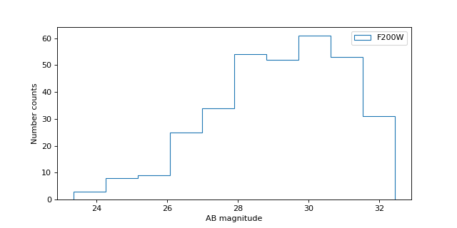

```python
fig = plt.figure(figsize=(8, 4))

filt = 'F200W'
mag1 = tbl[filt + '_mag']

mag1 = mag1[(0 < mag1) & (mag1 < 90)]  # detections only
n = plt.hist(mag1, histtype='step', label=filt)

plt.xlabel('AB magnitude')
plt.ylabel('Number counts')
plt.legend()
```

## Plot F200W vs. F090W magnitudes and look for dropouts

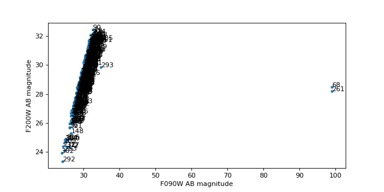

```python
#import mplcursors
# Would love a better solution here!

mag1 = tbl['F090W_mag']
mag2 = tbl['F200W_mag']

# Only plot detections in F200W
det2 = (0 < mag2) & (mag2 < 90)

mag1 = mag1[det2]
mag2 = mag2[det2]
ids = tbl['id'][det2]

plt.figure(figsize=(8, 4))

plt.plot(mag1, mag2, '.')

for i in range(len(mag1)):
    plt.text(mag1[i], mag2[i], ids[i])

plt.xlabel('F090W AB magnitude')
plt.ylabel('F200W AB magnitude')
```

## Look at one object

```python
# Could select object by position
#x, y = 905, 276
#id = segm.data[y,x]

# Select by ID number
id = 261  # F090W dropout
obj = tbl[id-1]
```

```python
obj
```

*Row index=260*

| id int64 | xcentroid pix float64 | ycentroid pix float64 | sky_centroid deg,deg object | area pix2 float64 | a pix float64 | b pix float64 | ellipticity float64 | orientation deg float64 | gini float64 | F090W_flux nJy float64 | F090W_fluxerr nJy float64 | F090W_mag float64 | F090W_magerr float64 | F115W_flux nJy float64 | F115W_fluxerr nJy float64 | F115W_mag float64 | F115W_magerr float64 | F150W_flux nJy float64 | F150W_fluxerr nJy float64 | F150W_mag float64 | F150W_magerr float64 | F200W_flux nJy float64 | F200W_fluxerr nJy float64 | F200W_mag float64 | F200W_magerr float64 | F277W_flux nJy float64 | F277W_fluxerr nJy float64 | F277W_mag float64 | F277W_magerr float64 | … |
| --- | --- | --- | --- | --- | --- | --- | --- | --- | --- | --- | --- | --- | --- | --- | --- | --- | --- | --- | --- | --- | --- | --- | --- | --- | --- | --- | --- | --- | --- | --- |
| 261 | 414.1268395854964 | 862.4411116880075 | 53.1743004694387,-27.79820710186078 | 77.0 | 2.957054912700376 | 1.4238175017603223 | 0.5185015010559627 | 60.2226641422329 | 0.37803089902883413 | -2.1520910685803947 | 0.7274671096066302 | 99.0 | 31.745466593275246 | 10.984612046975993 | 0.9890244833182839 | 28.798038192064137 | 0.09360336866209366 | 19.167396189662977 | 1.457642681570147 | 28.193592200494777 | 0.07957913979770254 | 19.362882878320427 | 1.5176442074434446 | 28.182574953708336 | 0.0819285970470171 | 13.273705753384169 | 0.5095076741975135 | 28.592519534668106 | 0.04089573737281089 | … |

```python
obj['ellipticity']
```

$0.5185015 \; \mathrm{}$

```python
segmobj = segm[segm.get_index(id)]
segmobj
```

```
<photutils.segmentation.core.Segment>
label: 261
slices: (slice(855, 870, None), slice(410, 419, None))
area: 77
```

## Show the object in all the images

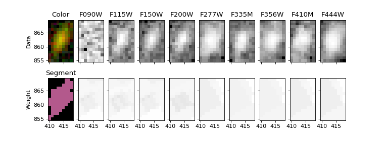

```python
fig, ax = plt.subplots(2, len(filters)+1, figsize=(9.5, 3.5), sharex=True, sharey=True)

ax[0, 0].imshow(rgb[segmobj.bbox.slices], origin='lower', extent=segmobj.bbox.extent)
ax[0, 0].set_title('Color')

cmap = segm.make_cmap(random_state=12345)  # ERROR
ax[1, 0].imshow(segm.data[segmobj.bbox.slices], origin='lower', extent=segmobj.bbox.extent, cmap=cmap,
               interpolation='nearest')
ax[1, 0].set_title('Segment')

for i in range(1, len(filters)+1):
    filt = filters[i-1]

    # Show data on top row
    data = fits.open(imagefiles[filt])[0].data
    stamp = data[segmobj.bbox.slices]
    norm = ImageNormalize(stretch=SqrtStretch())  # scale each filter individually
    ax[0, i].imshow(stamp, extent=segmobj.bbox.extent, cmap='Greys_r', norm=norm, origin='lower')
    ax[0, i].set_title(filt.upper())

    # Show weights on bottom row
    weight = fits.open(weightfiles[filt])[0].data
    stamp = weight[segmobj.bbox.slices]
    # set black to zero weight (no exposure time / bad pixel)
    ax[1, i].imshow(stamp, extent=segmobj.bbox.extent, vmin=0, cmap='Greys_r', origin='lower')

ax[0, 0].set_ylabel('Data')
ax[1, 0].set_ylabel('Weight')
```

## Plot SED (Spectral Energy Distribution)

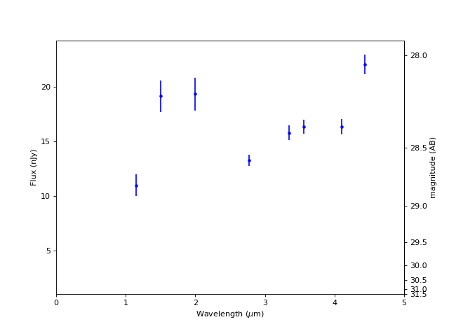

```python
fig, ax = plt.subplots(figsize=(8, 6))

for filt in filters:
    lam = int(filt[1:4]) / 100
    plt.errorbar(lam, obj[filt+'_flux'].value, obj[filt+'_fluxerr'].value, marker='.', c='b')

plt.axhline(0, c='k', ls=':')
plt.xlim(0, 5)
plt.xlabel('Wavelength ($\mu$m)')
plt.ylabel('Flux (nJy)')

mlim = 31.4
flim = mlim * u.ABmag
flim = flim.to(u.nJy).value

# Add AB magnitudes as secondary x-axis at right
# https://matplotlib.org/gallery/subplots_axes_and_figures/secondary_axis.html#sphx-glr-gallery-subplots-axes-and-figures-secondary-axis-py
def AB2nJy(mAB):
    m = mAB * u.ABmag
    f = m.to(u.nJy)
    f = f.value
    f = np.where(f > flim, f, flim)
    return f

def nJy2AB(F_nJy):
    f = F_nJy * u.nJy
    m = f.to(u.ABmag)
    m = m.value
    m = np.where(m < mlim, m, mlim)
    return m

plt.ylim(flim, plt.ylim()[1])

secax = ax.secondary_yaxis('right', functions=(nJy2AB, AB2nJy))
secax.set_ylabel('magnitude (AB)')
```

## Magnitude conversion fails for flux <= 0

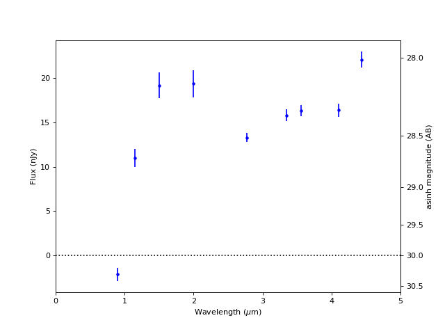

```python
fig, ax = plt.subplots(figsize=(8, 6))

for filt in filters:
    lam = int(filt[1:4]) / 100
    plt.errorbar(lam, obj[filt+'_flux'].value, obj[filt+'_fluxerr'].value, marker='.', c='b')

plt.axhline(0, c='k', ls=':')
plt.xlim(0, 5)
plt.xlabel('Wavelength ($\mu$m)')
plt.ylabel('Flux (nJy)')

f0 = 10**(0.4 * 31.4)  # flux [nJy] at zero magnitude
b0 = 1.e-12  # this should be filter dependent

# Add AB magnitudes as secondary x-axis at right
# https://matplotlib.org/gallery/subplots_axes_and_figures/secondary_axis.html#sphx-glr-gallery-subplots-axes-and-figures-secondary-axis-py
def AB2nJy(m):
    f = np.sinh(-0.4 * m * np.log(10) - np.log(b0)) * 2 * b0 * f0
    return f

# Luptitudes
# https://www.sdss.org/dr12/algorithms/magnitudes/
def nJy2AB(f):
    m = -2.5 / np.log(10) * (np.arcsinh((f / f0) / (2 * b0)) + np.log(b0))
    return m

#plt.ylim(flim, plt.ylim()[1])

secax = ax.secondary_yaxis('right', functions=(nJy2AB, AB2nJy))
secax.set_ylabel('asinh magnitude (AB)')
```